# Dataset 2g Simulation

For Dataset 2g -> simulate 50 subjects at one timepoint using the SPIEC EASI data simulation functions. I will use the same data from the Dataset 2f; (1) 50 subjects, 50 taxa (2) 100 subjects, 50 taxa (3) 50 subjects, 100 taxa

# 1. Load Library

```r
library(tidyverse)
library(igraph)
library(NBZIMM)
library(SpiecEasi)
library(LIMON)
library(here)
library(lme4)
library(Matrix)
library(tscount)
library(patchwork)
library(MASS)
library(matrixcalc)
library(gridExtra)
library(devtools)
library(miaSim)
library(reshape2)
library(corpcor)
library(Matrix)
```

# 2. 50 subjects 50 taxa Data

```r
# Pull Data
Subj50_Taxa50 <- read.csv(here("Data","GLV_SimData",
                               "Dataset_2f", "GLV_T2.csv"))
Subj50_Taxa50 <- Subj50_Taxa50 %>% column_to_rownames("X")
Subj50_Taxa50 <- Subj50_Taxa50[,3:52]

d <- ncol(Subj50_Taxa50)
n <- nrow(Subj50_Taxa50)
e <- d
```

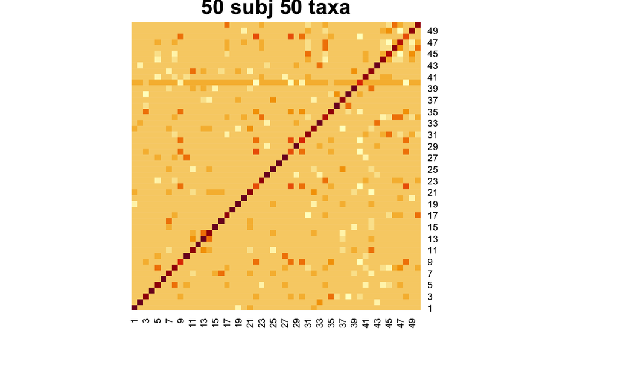

```r
# Synthesize
set.seed(10010)
graph <- SpiecEasi::make_graph('cluster', d, e)
set.seed(10010)
Prec  <- graph2prec(graph)
set.seed(10010)
Cor1  <- round(cov2cor(prec2cov(Prec)), 6)
set.seed(10010)
X <- synth_comm_from_counts(Subj50_Taxa50, mar=2, distr='zinegbin', Sigma=Cor1, n=n)

# Add Row and column names
rownames(X) <- rownames(Subj50_Taxa50)
colnames(X) <- colnames(Subj50_Taxa50)

# Heatmap
heatmap(Cor1, Colv = NA, Rowv = NA, main = "50 subj 50 taxa")
```

```r
# Save the File
write.csv(X,here("Data","GLV_SimData","Dataset_2g", "SE_50sbj50taxa.csv"))
write.csv(Cor1,here("Data","GLV_SimData","Dataset_2g", "Cor_50sbj50taxa.csv"))
```

# 3. 100 subjects 50 taxa Data

```r
# Pull Data
Subj100_Taxa50 <- read.csv(here("Data","GLV_SimData",
                               "Dataset_2f", "GLV_100_T2.csv"))
Subj100_Taxa50 <- Subj100_Taxa50 %>% column_to_rownames("X")
Subj100_Taxa50 <- Subj100_Taxa50[,3:52]

d <- ncol(Subj100_Taxa50)
n <- nrow(Subj100_Taxa50)
e <- d
```

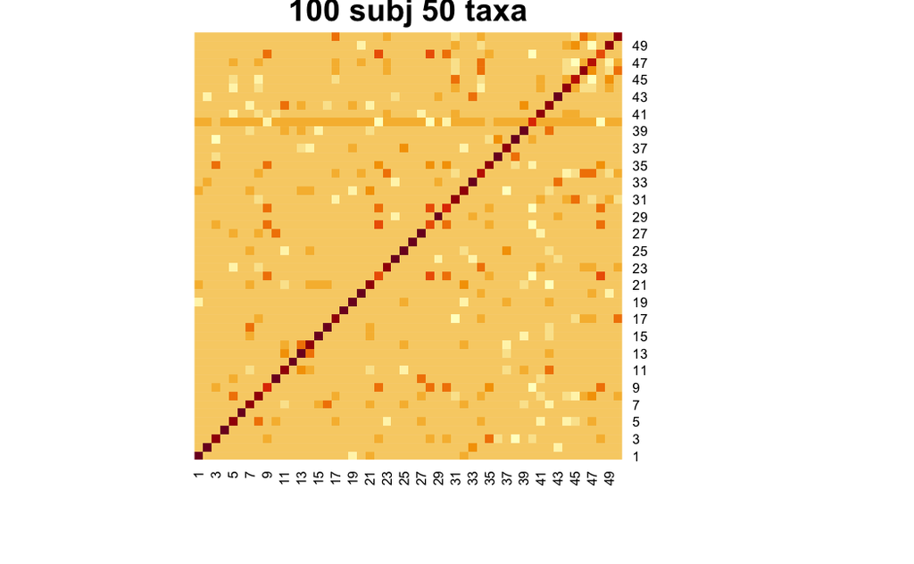

```r
# Synthesize
set.seed(10010)
graph <- SpiecEasi::make_graph('cluster', d, e)
set.seed(10010)
Prec  <- graph2prec(graph)
set.seed(10010)
Cor1  <- round(cov2cor(prec2cov(Prec)), 6)
set.seed(10010)
X <- synth_comm_from_counts(Subj100_Taxa50,
                            mar=2, distr='zinegbin', Sigma=Cor1, n=n)

# Add Row and column names
rownames(X) <- rownames(Subj100_Taxa50)
colnames(X) <- colnames(Subj100_Taxa50)

# Heatmap
heatmap(Cor1, Colv = NA, Rowv = NA, main = "100 subj 50 taxa")
```

```r
# Save the File
write.csv(X,here("Data","GLV_SimData","Dataset_2g", "SE_100sbj50taxa.csv"))
write.csv(Cor1,here("Data","GLV_SimData","Dataset_2g", "Cor_100sbj50taxa.csv"))
```

# 4. 50 subjects 100 taxa Data

```r
# Pull Data
Subj50_Taxa100 <- read.csv(here("Data","GLV_SimData",
                               "Dataset_2f", "GLV_100sp_T2.csv"))
Subj50_Taxa100 <- Subj50_Taxa100 %>% column_to_rownames("X")
Subj50_Taxa100 <- Subj50_Taxa100[,3:102]

d <- ncol(Subj50_Taxa100)
n <- nrow(Subj50_Taxa100)
e <- d
```

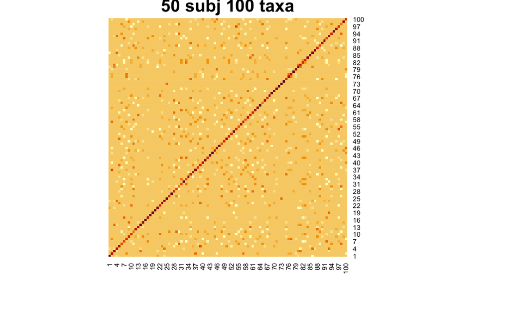

```r
# Synthesize
set.seed(10010)
graph <- SpiecEasi::make_graph('cluster', d, e)
set.seed(10010)
Prec  <- graph2prec(graph)
set.seed(10010)
Cor1  <- round(cov2cor(prec2cov(Prec)), 6)
set.seed(10010)
X <- synth_comm_from_counts(Subj50_Taxa100,
                            mar=2, distr='zinegbin', Sigma=Cor1, n=n)

# Add Row and column names
rownames(X) <- rownames(Subj50_Taxa100)
colnames(X) <- colnames(Subj50_Taxa100)

# Heatmap
heatmap(Cor1, Colv = NA, Rowv = NA, main = "50 subj 100 taxa")
```

```r
# Save the File
write.csv(X,here("Data","GLV_SimData","Dataset_2g", "SE_50sbj100taxa.csv"))
write.csv(Cor1,here("Data","GLV_SimData","Dataset_2g", "Cor_50sbj100taxa.csv"))
```

# 5. 100 subjects 100 taxa Data

```r
# Pull Data
Subj100_Taxa100 <- read.csv(here("Data","GLV_SimData",
                               "Dataset_2f", "GLV_100_100sp_T2.csv"))
Subj100_Taxa100 <- Subj100_Taxa100 %>% column_to_rownames("X")
Subj100_Taxa100 <- Subj100_Taxa100[,3:102]

d <- ncol(Subj100_Taxa100)
n <- nrow(Subj100_Taxa100)
e <- d
```

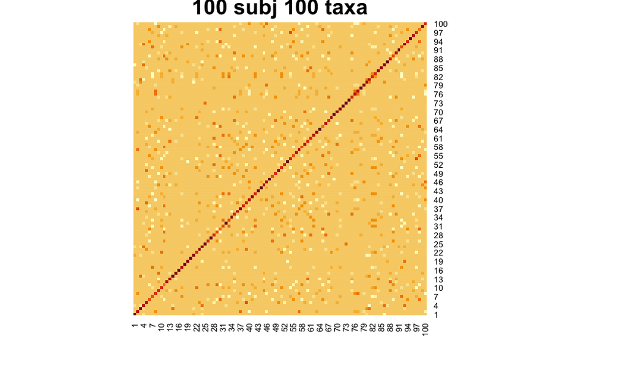

```r
# Synthesize
set.seed(10010)
graph <- SpiecEasi::make_graph('cluster', d, e)
set.seed(10010)
Prec  <- graph2prec(graph)
set.seed(10010)
Cor1  <- round(cov2cor(prec2cov(Prec)), 6)
set.seed(10010)
X <- synth_comm_from_counts(Subj100_Taxa100,
                            mar=2, distr='zinegbin', Sigma=Cor1, n=n)

# Add Row and column names
rownames(X) <- rownames(Subj100_Taxa100)
colnames(X) <- colnames(Subj100_Taxa100)

# Heatmap
heatmap(Cor1, Colv = NA, Rowv = NA, main = "100 subj 100 taxa")
```

```r
# Save the File
write.csv(X,here("Data","GLV_SimData","Dataset_2g", "SE_100sbj100taxa.csv"))
write.csv(Cor1,here("Data","GLV_SimData","Dataset_2g",
                    "Cor_100sbj100taxa.csv"))
```

# 6. 10% Changes

50 subjects, 100 species. Have the core true graph, then change 10% of the edges Loop -> Take the graph above, randomly change 10% (10 edges), simulate for that person

Check which edges in graph arent 0, change one of those taxa to zero in different subjects

```r
# Starting Graph Structure
########################################
d <- ncol(Subj50_Taxa100)
n <- nrow(Subj50_Taxa100)
e <- d
set.seed(10010)
graph <- SpiecEasi::make_graph('cluster', d, e)
set.seed(10010)
Prec  <- graph2prec(graph)
set.seed(10010)
Cor1_alt  <- round(cov2cor(prec2cov(Prec)), 6)
set.seed(10010)
X <- synth_comm_from_counts(Subj50_Taxa100,
                            mar=2, distr='zinegbin', Sigma=Cor1, n=n)

# Add Row and column names
rownames(X) <- rownames(Subj50_Taxa100)
colnames(X) <- colnames(Subj50_Taxa100)


# Create a list to store the new covariance matrices
########################################
Adj_list <- list()
Counts_list <- list()
Changed_Indices <- list()


# Chose 20 indices to choose from, then sample 10 from there to randomly
############################################################

# Get list of non zero edges
upper_tri_indices <- which(upper.tri(Cor1_alt), arr.ind = TRUE)

nonzero_indices <- upper_tri_indices[which(Cor1_alt[upper_tri_indices] != 0),
                                       , drop = FALSE]


# Loop to create 50 graphs that are mostly the same
############################################################
for(i in 1:50){

  # Select a non-zero edge
  set.seed(12345 + i)
  selected_nonzeros <- nonzero_indices[sample(nrow(nonzero_indices), 1),, drop = FALSE]

  # Store the changed indices for this iteration
  Changed_Indices[[i]] <- list(nonzero_to_zero = selected_nonzeros)


  # change one of the values to 0
  X_i <- Subj50_Taxa100[i,]
  X_i[,selected_nonzeros] <- 0

  # Save Both to Lists
  Counts_list[[i]] <- X_i
}
```

```r
# Starting Graph Structure
########################################
d <- ncol(Subj50_Taxa100)
n <- nrow(Subj50_Taxa100)
e <- d
set.seed(10010)
graph <- SpiecEasi::make_graph('cluster', d, e)
set.seed(10010)
Prec  <- graph2prec(graph)
set.seed(10010)
Cor1_alt  <- round(cov2cor(prec2cov(Prec)), 6)
set.seed(10010)
X <- synth_comm_from_counts(Subj50_Taxa100,
                            mar=2, distr='zinegbin', Sigma=Cor1_alt, n=n)

# Add Row and column names
rownames(X) <- rownames(Subj50_Taxa100)
colnames(X) <- colnames(Subj50_Taxa100)

# Create lists to store modified matrices
########################################
Adj_list <- list()
Counts_list <- list()
Changed_Indices <- list()

# Get list of nonzero edges
upper_tri_indices <- which(upper.tri(Cor1_alt), arr.ind = TRUE)

nonzero_indices <- upper_tri_indices[which(Cor1_alt[upper_tri_indices] != 0), , drop = FALSE]


# Loop to create 50 modified count matrices
############################################################
for(i in 1:50){

  # Select a nonzero edge
  set.seed(12345 + i)
  selected_edge <- nonzero_indices[sample(nrow(nonzero_indices), 1), , drop = FALSE]

  # Extract one taxa index
  taxa_to_zero <- as.numeric(selected_edge[1,1])
  taxa_to_zero <- paste("sp",taxa_to_zero, sep="")

  # Store changed indices
  Changed_Indices[[i]] <- taxa_to_zero

  # Modify the count
  X_i <- as.data.frame(t(X[i,]))
  X_i[1,taxa_to_zero] <- 0

  # Save new count matrix
  Counts_list[[i]] <- X_i
}
```

```r
# Combine the count tables
Subj50_Taxa100_90 <- do.call(rbind, Counts_list)
```

Get the indices of the altered edges

```r
# Start list
all_changes <- list()

# Loop over the iterations
for (i in seq_along(Changed_Indices)) {

  nonzero_to_zero_df <- data.frame(Source = Changed_Indices[[i]],
                                   Change_Type = "nonzero_to_zero",
                                   SubjectID = i)

  # Combine
  all_changes[[i]] <- bind_rows(nonzero_to_zero_df)
}

# Bind together and fix sample names
Subj50_Taxa100_90_indices <- bind_rows(all_changes)
Subj50_Taxa100_90_indices$SubjectID <- paste0("Sbj", Subj50_Taxa100_90_indices$SubjectID)
Subj50_Taxa100_90_indices$SubjectID <- paste0(Subj50_Taxa100_90_indices$SubjectID, "_Time2")

# check how many unique changed
length(unique(Subj50_Taxa100_90_indices$Source))
```

```
[1] 40
```

```r
# Save the File
write.csv(Subj50_Taxa100_90,
          here("Data","GLV_SimData","Dataset_2g", "SE_50sbj100taxa_90.csv"))

write.csv(Subj50_Taxa100_90_indices,
          here("Data","GLV_SimData","Dataset_2g", "50sbj100taxa_90indices.csv"))
```

# 7. Strong edge shuffle

Generate a total of 8 datasets

In the first iteration we will generate 4 datasets. Pick the top 3 or 5 non overlapping edges (~5%, 10%) and set one of those taxa to 0 in 1 or 5 subjects

In the second iteration, we will generate 4 datasets again. But now pick the weakest 3-5 non overlapping edges and make the counts of both of those taxa higher than the mean or doubled. In 1 or 5 subjects again

## 7.1 - Strong to Weak

Iteration 1

```r
# Get Indices Without Overlapping Taxa
#######################################################

unique_edges <- function(cor_matrix, upper_tri_indices, n) {
  selected_edges <- matrix(nrow = 0, ncol = 2)
  used_taxa <- c()

  # Order by abs cor value
  ordered_edges <- order(abs(cor_matrix[upper_tri_indices]), decreasing = TRUE)

  for (idx in ordered_edges) {
    edge <- upper_tri_indices[idx, , drop = FALSE]

    # Extract taxa from edge
    taxa_1 <- edge[1, 1]
    taxa_2 <- edge[1, 2]

    # Check if already used
    if (!(taxa_1 %in% used_taxa || taxa_2 %in% used_taxa)) {
      selected_edges <- rbind(selected_edges, edge)
      used_taxa <- c(used_taxa, taxa_1, taxa_2)
    }

    if (nrow(selected_edges) == n) break
  }

  return(selected_edges)
}


# Top 3 Edges Without Overlap
Edge_3 <- unique_edges(Cor1_alt, upper_tri_indices, 3)

# Top 5 Edges Without Overlap
Edge_5 <- unique_edges(Cor1_alt, upper_tri_indices, 5)

# Get N Value (Random Subjects)
#######################################################
set.seed(12345)
N1 <- sample(rownames(X), 1)

set.seed(12345)
N5 <- sample(rownames(X), 5)
```

Shuffle_N1_I3 Shuffle_N5_I3

```r
# Shuffle 3 index in 1 subject
###########################################
Shuffle_N1_I3 <- X

# Loop over the subjects
for (i in seq_along(N1)) {

  # Specify rowname (subject ID)
  sbj <- N1[i]

  # Loop over the top 3 strongest edges and set one of their species to 0
  for (j in 1:3) {
    # Taxa 1
    taxa_1 <- as.numeric(Edge_3[j,1])
    taxa_1 <- paste("sp", taxa_1, sep = "")


    # Swap the values
    Shuffle_N1_I3[sbj, taxa_1] <- 0
  }
}

check <- X - Shuffle_N1_I3



# Shuffle 3 index in 5 subject
###########################################
Shuffle_N5_I3 <- X

# Loop over the subjects
for (i in seq_along(N5)) {

  # Specify rowname (subject ID)
  sbj <- N5[i]

  # Loop over the top 3 edges
  for (j in 1:3) {
    # Taxa 1
    taxa_1 <- as.numeric(Edge_3[j,1])
    taxa_1 <- paste("sp", taxa_1, sep = "")

    # Swap the values
    Shuffle_N5_I3[sbj, taxa_1] <- 0
  }
}

check <- X - Shuffle_N5_I3
```

Shuffle_N1_I5 Shuffle_N5_I5

```r
# Shuffle 5 index in 1 subject
###########################################
Shuffle_N1_I5 <- X

# Loop over the subjects
for (i in seq_along(N1)) {

  # Specify rowname (subject ID)
  sbj <- N1[i]

  # Loop over the top 5 strongest edges and set one of their species to 0
  for (j in 1:5) {
    # Taxa 1
    taxa_1 <- as.numeric(Edge_5[j,1])
    taxa_1 <- paste("sp", taxa_1, sep = "")


    # Swap the values
    Shuffle_N1_I5[sbj, taxa_1] <- 0
  }
}

check <- X - Shuffle_N1_I5



# Shuffle 5 index in 5 subject
###########################################
Shuffle_N5_I5 <- X

# Loop over the subjects
for (i in seq_along(N5)) {

  # Specify rowname (subject ID)
  sbj <- N5[i]

  # Loop over the top 5 edges
  for (j in 1:5) {
    # Taxa 1
    taxa_1 <- as.numeric(Edge_5[j,1])
    taxa_1 <- paste("sp", taxa_1, sep = "")

    # Swap the values
    Shuffle_N5_I5[sbj, taxa_1] <- 0
  }
}

check <- X - Shuffle_N5_I5
```

## 7.2 - Weak to Strong

Iteration 2

```r
# Get Indices Without Overlapping Taxa
#######################################################

unique_edges <- function(cor_matrix, upper_tri_indices, n) {
  selected_edges <- matrix(nrow = 0, ncol = 2)
  used_taxa <- c()

  # Order by abs cor value
  ordered_edges <- order(abs(cor_matrix[upper_tri_indices]), decreasing = FALSE)

  for (idx in ordered_edges) {
    edge <- upper_tri_indices[idx, , drop = FALSE]

    # Extract taxa from edge
    taxa_1 <- edge[1, 1]
    taxa_2 <- edge[1, 2]

    # Check if already used
    if (!(taxa_1 %in% used_taxa || taxa_2 %in% used_taxa)) {
      selected_edges <- rbind(selected_edges, edge)
      used_taxa <- c(used_taxa, taxa_1, taxa_2)
    }

    if (nrow(selected_edges) == n) break
  }

  return(selected_edges)
}


# Top 3 Edges Without Overlap
Edge_3low <- unique_edges(Cor1_alt, upper_tri_indices, 3)

# Top 5 Edges Without Overlap
Edge_5low <- unique_edges(Cor1_alt, upper_tri_indices, 5)

# Get N Value (Random Subjects)
#######################################################
set.seed(12345)
N1 <- sample(rownames(X), 1)

set.seed(12345)
N5 <- sample(rownames(X), 5)
```

Shuffle_N1_I3_low Shuffle_N5_I3_low

```r
# Shuffle 3 index in 1 subject
###########################################
Shuffle_N1_I3_low <- X

# Loop over the subjects
for (i in seq_along(N1)) {

  # Specify rowname (subject ID)
  sbj <- N1[i]

  # Loop over the lowest 3 edges and double both their counts
  for (j in 1:3) {

    # Taxa 1
    taxa_1 <- as.numeric(Edge_3low[j,1])
    taxa_1 <- paste("sp", taxa_1, sep = "")
    taxa_1_val <- Shuffle_N1_I3_low[sbj,taxa_1]

    # Taxa 2
    taxa_2 <- as.numeric(Edge_3low[j,2])
    taxa_2 <- paste("sp", taxa_2, sep = "")
    taxa_2_val <- Shuffle_N1_I3_low[sbj,taxa_2]

    # Swap the values
    Shuffle_N1_I3_low[sbj, taxa_1] <- taxa_1_val*2
    Shuffle_N1_I3_low[sbj, taxa_2] <- taxa_2_val*2
  }
}

check <- X - Shuffle_N1_I3_low



# Shuffle 3 index in 5 subject
###########################################
Shuffle_N5_I3_low <- X

# Loop over the subjects
for (i in seq_along(N5)) {

  # Specify rowname (subject ID)
  sbj <- N5[i]

  # Loop over lowest 5 edges and double their counts
  for (j in 1:3) {

    # Taxa 1
    taxa_1 <- as.numeric(Edge_3low[j,1])
    taxa_1 <- paste("sp", taxa_1, sep = "")
    taxa_1_val <- Shuffle_N5_I3_low[sbj,taxa_1]

    # Taxa 2
    taxa_2 <- as.numeric(Edge_3low[j,2])
    taxa_2 <- paste("sp", taxa_2, sep = "")
    taxa_2_val <- Shuffle_N5_I3_low[sbj,taxa_2]

    # Swap the values
    Shuffle_N5_I3_low[sbj, taxa_1] <- taxa_1_val*2
    Shuffle_N5_I3_low[sbj, taxa_2] <- taxa_2_val*2
  }
}

check <- X - Shuffle_N5_I3_low
```

Shuffle_N1_I5_low Shuffle_N5_I5_low

```r
# Shuffle 3 index in 1 subject
###########################################
Shuffle_N1_I5_low <- X

# Loop over the subjects
for (i in seq_along(N1)) {

  # Specify rowname (subject ID)
  sbj <- N1[i]

  # Loop over the lowest 5 edges and double both their counts
  for (j in 1:5) {

    # Taxa 1
    taxa_1 <- as.numeric(Edge_5low[j,1])
    taxa_1 <- paste("sp", taxa_1, sep = "")
    taxa_1_val <- Shuffle_N1_I5_low[sbj,taxa_1]

    # Taxa 2
    taxa_2 <- as.numeric(Edge_5low[j,2])
    taxa_2 <- paste("sp", taxa_2, sep = "")
    taxa_2_val <- Shuffle_N1_I5_low[sbj,taxa_2]

    # Swap the values
    Shuffle_N1_I5_low[sbj, taxa_1] <- taxa_1_val*2
    Shuffle_N1_I5_low[sbj, taxa_2] <- taxa_2_val*2
  }
}

check <- X - Shuffle_N1_I5_low



# Shuffle 5 index in 5 subject
###########################################
Shuffle_N5_I5_low <- X

# Loop over the subjects
for (i in seq_along(N5)) {

  # Specify rowname (subject ID)
  sbj <- N5[i]

  # Loop over lowest 5 edges and double their counts
  for (j in 1:5) {

    # Taxa 1
    taxa_1 <- as.numeric(Edge_5low[j,1])
    taxa_1 <- paste("sp", taxa_1, sep = "")
    taxa_1_val <- Shuffle_N5_I5_low[sbj,taxa_1]

    # Taxa 2
    taxa_2 <- as.numeric(Edge_5low[j,2])
    taxa_2 <- paste("sp", taxa_2, sep = "")
    taxa_2_val <- Shuffle_N5_I5_low[sbj,taxa_2]

    # Swap the values
    Shuffle_N5_I5_low[sbj, taxa_1] <- taxa_1_val*2
    Shuffle_N5_I5_low[sbj, taxa_2] <- taxa_2_val*2
  }
}

check <- X - Shuffle_N5_I5_low
```

## 7.3 - Save the Data

Save the Data

```r
# Iteration 1
#################################################################
# N1, I3
write.csv(Shuffle_N1_I3, here("Data","GLV_SimData","Dataset_2g",
                              "Shuffle_N1_I3.csv"))
# N5, I3
write.csv(Shuffle_N5_I3, here("Data","GLV_SimData","Dataset_2g",
                              "Shuffle_N5_I3.csv"))

# N1, I5
write.csv(Shuffle_N1_I5, here("Data","GLV_SimData","Dataset_2g",
                              "Shuffle_N1_I5.csv"))

# N5, I5
write.csv(Shuffle_N5_I5, here("Data","GLV_SimData","Dataset_2g",
                              "Shuffle_N5_I5.csv"))


# Iteration 2
#################################################################
# N1, I3
write.csv(Shuffle_N1_I3_low, here("Data","GLV_SimData","Dataset_2g",
                              "Shuffle_N1_I3_low.csv"))
# N5, I3
write.csv(Shuffle_N5_I3_low, here("Data","GLV_SimData","Dataset_2g",
                              "Shuffle_N5_I3_low.csv"))

# N1, I5
write.csv(Shuffle_N1_I5_low, here("Data","GLV_SimData","Dataset_2g",
                              "Shuffle_N1_I5_low.csv"))

# N5, I5
write.csv(Shuffle_N5_I5_low, here("Data","GLV_SimData","Dataset_2g",
                              "Shuffle_N5_I5_low.csv"))
```